# DA 101 Week 3

Prof Miller

05 February, 2020

## Cool example: Death Penalty Data

First, download and load the csv.

```r
deathData <- read.csv("death penalty data.csv")
head(deathData)
```

|  | Date | Name | Age | Sex | Race | Crime | Victim.Count | Victim.Sex | Victim.Race | County | State | Region | Method | Juvenile | Volunteer | Federal | Foreign.National |
| --- | --- | --- | --- | --- | --- | --- | --- | --- | --- | --- | --- | --- | --- | --- | --- | --- | --- |
| 1 | 01/17/1977 | Gary Gilmore | 36 | Male | White | Murder | 1 | Male | White | Utah | UT | West | Firing Squad | No | Yes | No | No |
| 2 | 05/25/1979 | John Spenkelink | 30 | Male | White | Murder | 1 | Male | White | Leon | FL | South | Electrocution | No | No | No | No |
| 3 | 10/22/1979 | Jesse Bishop | 46 | Male | White | Murder | 1 | Male | White | Clark | NV | West | Gas Chamber | No | Yes | No | No |
| 4 | 03/09/1981 | Steven Judy | 24 | Male | White | Murder | 4 | 2 Male, 2 Female | White | Marion | IN | Midwest | Electrocution | No | Yes | No | No |
| 5 | 08/10/1982 | Frank Coppola | 38 | Male | White | Murder | 1 | Male | White | Newport News City | VA | South | Electrocution | No | Yes | No | No |
| 6 | 12/07/1982 | Charlie Brooks | 40 | Male | Black | Murder | 1 | Male | White | Tarrant | TX | South | Lethal Injection | No | No | No | No |

About the data: the death penalty was illegal for decades after the civil war. A supreme cour case in the 70s (1977) legalized it again. This data is a list of everyone who’s received the death penalty since then.

Q: What about race?

Idea: histogram

Can’t do histo, not numeric!

Scatterplot doesn’t make sense, that’s for two numerical variables.

```r
#ggplot(deathData, aes(x=Race))+geom_histogram()
```

SInce we’re working with categorical data, need a barplot!

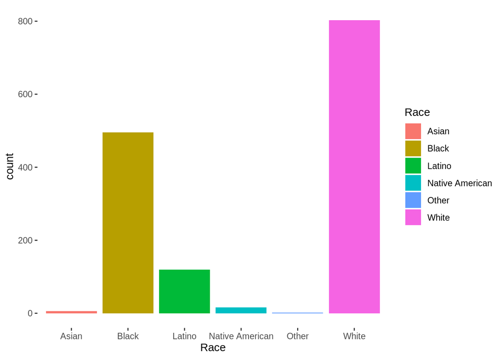

```r
ggplot(deathData, aes(Race, fill=Race))+geom_bar()
```

Woah! Does this match up with US demographics? I think not! Follow-up question:  
- what are the demographics of the us - what prorortions are we actually seeing here - is there a statistically significant difference from population? - are particular groups disproportionately receiving the death penalty?

Technique: prop tables

They’re easy in R: use table()

```r
table(deathData$Race) %>% prop.table()
```

```
##
##           Asian           Black          Latino Native American
##     0.004160888     0.343273232     0.083217753     0.011095700
##           Other           White
##     0.001386963     0.556865465
```

# Monday

## More examples with death penalty

```r
deathData <- read.csv("death penalty data.csv")
head(deathData)
```

|  | Date | Name | Age | Sex | Race | Crime | Victim.Count | Victim.Sex | Victim.Race | County | State | Region | Method | Juvenile | Volunteer | Federal | Foreign.National |
| --- | --- | --- | --- | --- | --- | --- | --- | --- | --- | --- | --- | --- | --- | --- | --- | --- | --- |
| 1 | 01/17/1977 | Gary Gilmore | 36 | Male | White | Murder | 1 | Male | White | Utah | UT | West | Firing Squad | No | Yes | No | No |
| 2 | 05/25/1979 | John Spenkelink | 30 | Male | White | Murder | 1 | Male | White | Leon | FL | South | Electrocution | No | No | No | No |
| 3 | 10/22/1979 | Jesse Bishop | 46 | Male | White | Murder | 1 | Male | White | Clark | NV | West | Gas Chamber | No | Yes | No | No |
| 4 | 03/09/1981 | Steven Judy | 24 | Male | White | Murder | 4 | 2 Male, 2 Female | White | Marion | IN | Midwest | Electrocution | No | Yes | No | No |
| 5 | 08/10/1982 | Frank Coppola | 38 | Male | White | Murder | 1 | Male | White | Newport News City | VA | South | Electrocution | No | Yes | No | No |
| 6 | 12/07/1982 | Charlie Brooks | 40 | Male | Black | Murder | 1 | Male | White | Tarrant | TX | South | Lethal Injection | No | No | No | No |

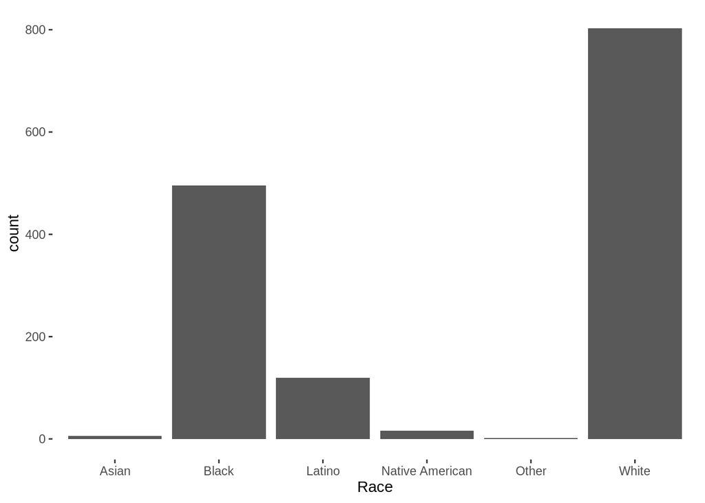

```r
library(dplyr)
library(ggplot2)

ggplot(deathData, aes(Race))+geom_bar()
```

WHat about a visual that shows a comparison/examination of the relationship of Race and Method (of execution)?

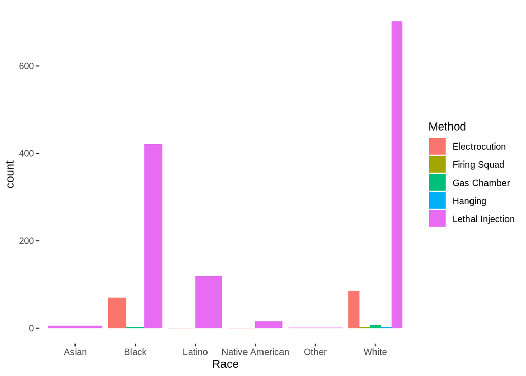

```r
ggplot(deathData, aes(Race, fill=Method))+geom_bar(position=position_dodge())
```

## Example: State

Use a visual to show -where- executions are occuring.

Idea: use a barplot for the (categorical) State variable!

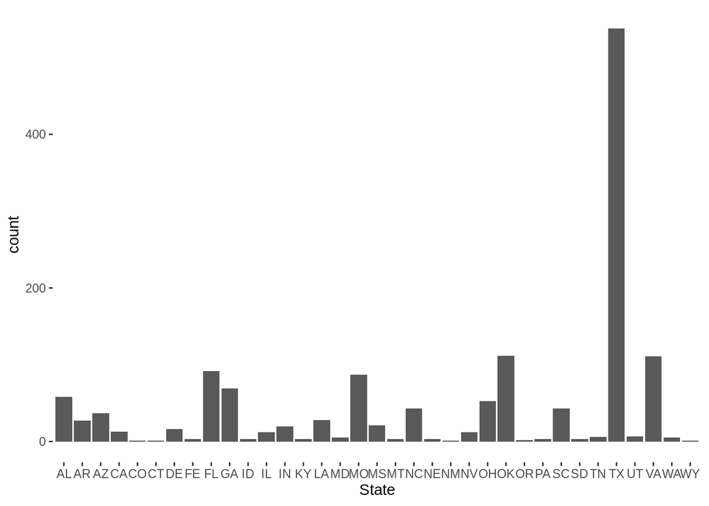

```r
ggplot(deathData, aes(State))+geom_bar()
```

Woah! TX, what’s up? So many more exectutions!

Moreover, seems like there’s just a handful of places where the death penalty is used.

Q: What if I want to study those states where death penalty is most common? I could use a filter!

Let’s try these states: AL, FL, GA, MO, OK, TX, VA

How can get a dataset with just these states? Filter! We can add many conditions with “or”: |

```r
highStates <- filter(deathData, State == "AL" | State == "FL"
                                | State ==  "GA"
                                | State == "MO"
                                | State == "OK"
                                | State == "TX"
                                | State == "VA")

head(highStates)
```

|  | Date | Name | Age | Sex | Race | Crime | Victim.Count | Victim.Sex | Victim.Race | County | State | Region | Method | Juvenile | Volunteer | Federal | Foreign.National |
| --- | --- | --- | --- | --- | --- | --- | --- | --- | --- | --- | --- | --- | --- | --- | --- | --- | --- |
| 1 | 05/25/1979 | John Spenkelink | 30 | Male | White | Murder | 1 | Male | White | Leon | FL | South | Electrocution | No | No | No | No |
| 2 | 08/10/1982 | Frank Coppola | 38 | Male | White | Murder | 1 | Male | White | Newport News City | VA | South | Electrocution | No | Yes | No | No |
| 3 | 12/07/1982 | Charlie Brooks | 40 | Male | Black | Murder | 1 | Male | White | Tarrant | TX | South | Lethal Injection | No | No | No | No |
| 4 | 04/22/1983 | John Evans | 33 | Male | White | Murder | 1 | Male | White | Mobile | AL | South | Electrocution | No | No | No | No |
| 5 | 11/30/1983 | Robert Sullivan | 36 | Male | White | Murder | 1 | Male | White | Miami-Dade | FL | South | Electrocution | No | No | No | No |
| 6 | 12/15/1983 | John Smith | 53 | Male | White | Murder | 2 | 1 Male, 1 Female | White | Bibb | GA | South | Electrocution | No | No | No | No |

```r
## did it work?  check with "unique"

unique(highStates$State)
```

```
## [1] FL VA TX AL GA MO OK
## 35 Levels: AL AR AZ CA CO CT DE FE FL GA ID IL IN KY LA MD MO MS MT ... WY
```

We’ve got it narrowed down. Let’s study those states. Q: Method. In those states, what methods are used?

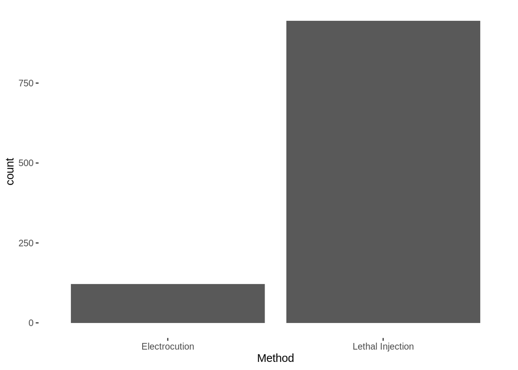

```r
ggplot(highStates, aes(Method))+geom_bar()
```

In these states, where capitol punishmen is used the most, we see that electrocution and Lethal Injection are the only methods used.

What about Race in those states? Let’s compare both Race and State.

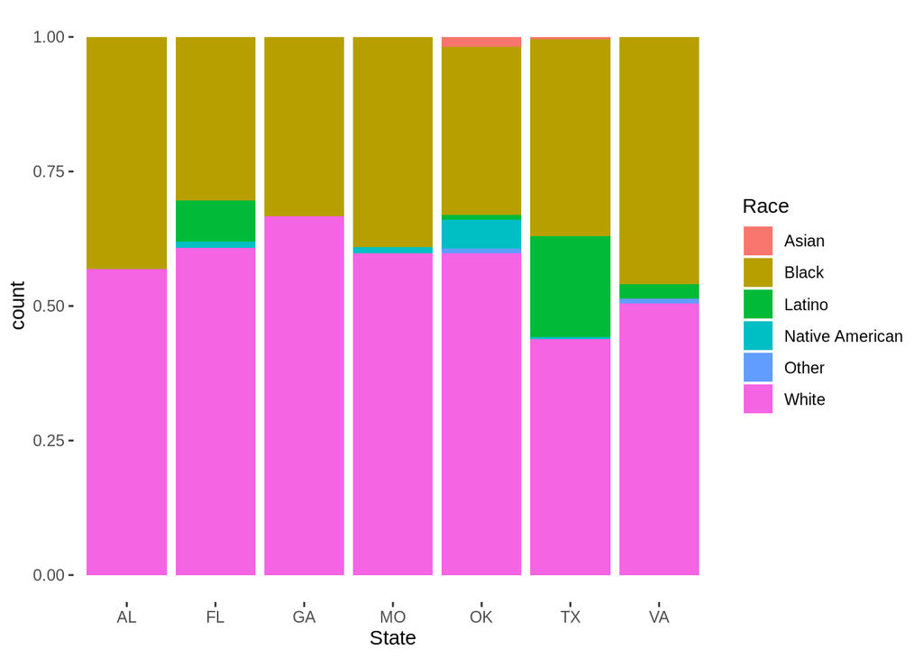

```r
ggplot(highStates, aes(State, fill=Race))+geom_bar(position="fill")
```

Notice here, we can compare ratios/percentages directly!

Interesting observation: why are so many (relatively) asian americans receiving the death penalty in OK??? Is there a story there?

## Example: WHen???

Q: Can we plot time trends in the death penalty?

```r
head(deathData)
```

|  | Date | Name | Age | Sex | Race | Crime | Victim.Count | Victim.Sex | Victim.Race | County | State | Region | Method | Juvenile | Volunteer | Federal | Foreign.National |
| --- | --- | --- | --- | --- | --- | --- | --- | --- | --- | --- | --- | --- | --- | --- | --- | --- | --- |
| 1 | 01/17/1977 | Gary Gilmore | 36 | Male | White | Murder | 1 | Male | White | Utah | UT | West | Firing Squad | No | Yes | No | No |
| 2 | 05/25/1979 | John Spenkelink | 30 | Male | White | Murder | 1 | Male | White | Leon | FL | South | Electrocution | No | No | No | No |
| 3 | 10/22/1979 | Jesse Bishop | 46 | Male | White | Murder | 1 | Male | White | Clark | NV | West | Gas Chamber | No | Yes | No | No |
| 4 | 03/09/1981 | Steven Judy | 24 | Male | White | Murder | 4 | 2 Male, 2 Female | White | Marion | IN | Midwest | Electrocution | No | Yes | No | No |
| 5 | 08/10/1982 | Frank Coppola | 38 | Male | White | Murder | 1 | Male | White | Newport News City | VA | South | Electrocution | No | Yes | No | No |
| 6 | 12/07/1982 | Charlie Brooks | 40 | Male | Black | Murder | 1 | Male | White | Tarrant | TX | South | Lethal Injection | No | No | No | No |

Idea: barplot?

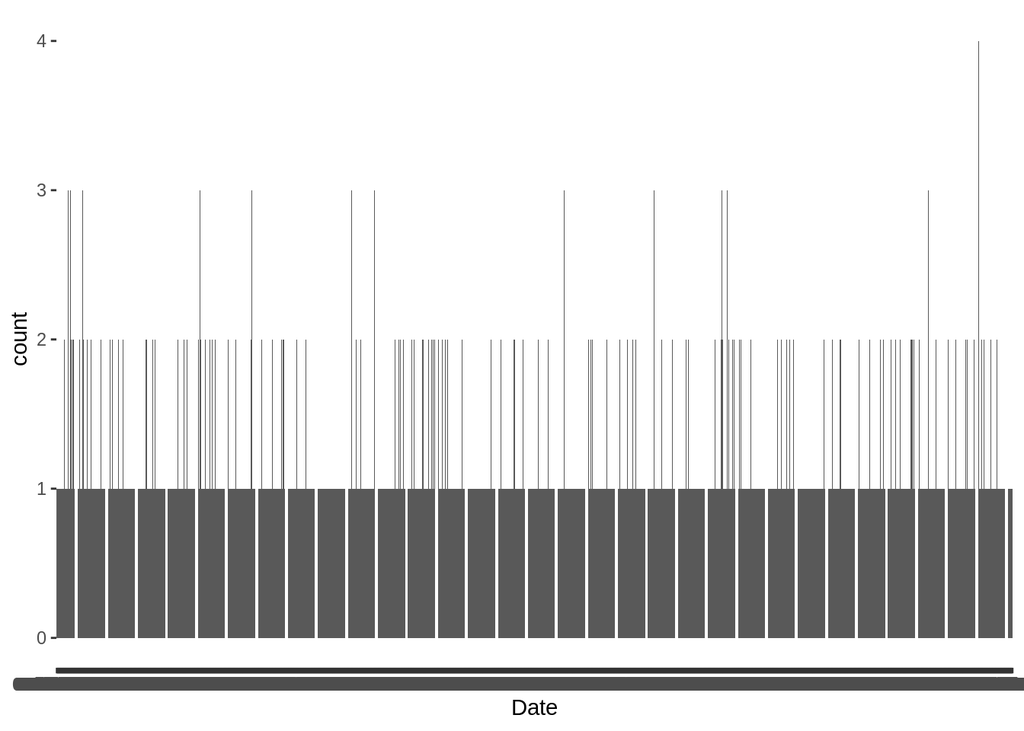

```r
ggplot(deathData, aes(Date))+geom_bar()
```

Bad plot. Basically: too many dates, and most only have one execution.

Problem: we want the YEAR, not the individual day. This is an example of “data wrangling”. Our dates aren’t in the right format.

```r
head(deathData)
```

|  | Date | Name | Age | Sex | Race | Crime | Victim.Count | Victim.Sex | Victim.Race | County | State | Region | Method | Juvenile | Volunteer | Federal | Foreign.National |
| --- | --- | --- | --- | --- | --- | --- | --- | --- | --- | --- | --- | --- | --- | --- | --- | --- | --- |
| 1 | 01/17/1977 | Gary Gilmore | 36 | Male | White | Murder | 1 | Male | White | Utah | UT | West | Firing Squad | No | Yes | No | No |
| 2 | 05/25/1979 | John Spenkelink | 30 | Male | White | Murder | 1 | Male | White | Leon | FL | South | Electrocution | No | No | No | No |
| 3 | 10/22/1979 | Jesse Bishop | 46 | Male | White | Murder | 1 | Male | White | Clark | NV | West | Gas Chamber | No | Yes | No | No |
| 4 | 03/09/1981 | Steven Judy | 24 | Male | White | Murder | 4 | 2 Male, 2 Female | White | Marion | IN | Midwest | Electrocution | No | Yes | No | No |
| 5 | 08/10/1982 | Frank Coppola | 38 | Male | White | Murder | 1 | Male | White | Newport News City | VA | South | Electrocution | No | Yes | No | No |
| 6 | 12/07/1982 | Charlie Brooks | 40 | Male | Black | Murder | 1 | Male | White | Tarrant | TX | South | Lethal Injection | No | No | No | No |

Problem: see “”? R thinks the dates are “categorical” variables! We want numbers.

R has built-in date functions. Use: as.Date()

Problem: we need to teach it the format.

```r
as.Date(deathData$Date, "%m/%d/%Y")
```

```
##    [1] "1977-01-17" "1979-05-25" "1979-10-22" "1981-03-09" "1982-08-10"
##    [6] "1982-12-07" "1983-04-22" "1983-09-02" "1983-11-30" "1983-12-14"
##   [11] "1983-12-15" "1984-01-26" "1984-02-29" "1984-03-14" "1984-03-16"
##   [16] "1984-03-31" "1984-04-05" "1984-04-05" "1984-05-10" "1984-06-20"
##   [21] "1984-07-12" "1984-07-13" "1984-09-07" "1984-09-10" "1984-09-20"
##   [26] "1984-10-12" "1984-10-30" "1984-10-30" "1984-11-02" "1984-11-08"
##   [31] "1984-12-12" "1984-12-28" "1985-01-04" "1985-01-09" "1985-01-11"
##   [36] "1985-01-16" "1985-01-30" "1985-02-20" "1985-03-06" "1985-03-13"
##   [41] "1985-03-20" "1985-04-18" "1985-05-15" "1985-05-29" "1985-06-25"
##   [46] "1985-06-25" "1985-07-09" "1985-09-11" "1985-10-16" "1985-12-06"
##   [51] "1986-01-10" "1986-03-12" "1986-03-21" "1986-04-15" "1986-04-16"
##   [56] "1986-04-22" "1986-05-15" "1986-05-20" "1986-06-09" "1986-06-19"
##   [61] "1986-06-24" "1986-07-31" "1986-08-20" "1986-08-22" "1986-08-26"
##   [66] "1986-09-19" "1986-12-04" "1986-12-18" "1987-01-30" "1987-03-04"
##   [71] "1987-05-15" "1987-05-20" "1987-05-22" "1987-05-28" "1987-05-29"
```

[output cut: 274 more lines]

```r
## We actually want to save this.  Be careful!  Don't destroy your data!  Make a copy.

myDeathData <- deathData  #backup

myDeathData$Date <- as.Date(deathData$Date, "%m/%d/%Y")

head(myDeathData)
```

|  | Date | Name | Age | Sex | Race | Crime | Victim.Count | Victim.Sex | Victim.Race | County | State | Region | Method | Juvenile | Volunteer | Federal | Foreign.National |
| --- | --- | --- | --- | --- | --- | --- | --- | --- | --- | --- | --- | --- | --- | --- | --- | --- | --- |
| 1 | 1977-01-17 | Gary Gilmore | 36 | Male | White | Murder | 1 | Male | White | Utah | UT | West | Firing Squad | No | Yes | No | No |
| 2 | 1979-05-25 | John Spenkelink | 30 | Male | White | Murder | 1 | Male | White | Leon | FL | South | Electrocution | No | No | No | No |
| 3 | 1979-10-22 | Jesse Bishop | 46 | Male | White | Murder | 1 | Male | White | Clark | NV | West | Gas Chamber | No | Yes | No | No |
| 4 | 1981-03-09 | Steven Judy | 24 | Male | White | Murder | 4 | 2 Male, 2 Female | White | Marion | IN | Midwest | Electrocution | No | Yes | No | No |
| 5 | 1982-08-10 | Frank Coppola | 38 | Male | White | Murder | 1 | Male | White | Newport News City | VA | South | Electrocution | No | Yes | No | No |
| 6 | 1982-12-07 | Charlie Brooks | 40 | Male | Black | Murder | 1 | Male | White | Tarrant | TX | South | Lethal Injection | No | No | No | No |

```r
# one more step:  format for just the year

myDeathData$Date <-  format(myDeathData$Date, "%Y")

head(myDeathData)
```

|  | Date | Name | Age | Sex | Race | Crime | Victim.Count | Victim.Sex | Victim.Race | County | State | Region | Method | Juvenile | Volunteer | Federal | Foreign.National |
| --- | --- | --- | --- | --- | --- | --- | --- | --- | --- | --- | --- | --- | --- | --- | --- | --- | --- |
| 1 | 1977 | Gary Gilmore | 36 | Male | White | Murder | 1 | Male | White | Utah | UT | West | Firing Squad | No | Yes | No | No |
| 2 | 1979 | John Spenkelink | 30 | Male | White | Murder | 1 | Male | White | Leon | FL | South | Electrocution | No | No | No | No |
| 3 | 1979 | Jesse Bishop | 46 | Male | White | Murder | 1 | Male | White | Clark | NV | West | Gas Chamber | No | Yes | No | No |
| 4 | 1981 | Steven Judy | 24 | Male | White | Murder | 4 | 2 Male, 2 Female | White | Marion | IN | Midwest | Electrocution | No | Yes | No | No |
| 5 | 1982 | Frank Coppola | 38 | Male | White | Murder | 1 | Male | White | Newport News City | VA | South | Electrocution | No | Yes | No | No |
| 6 | 1982 | Charlie Brooks | 40 | Male | Black | Murder | 1 | Male | White | Tarrant | TX | South | Lethal Injection | No | No | No | No |

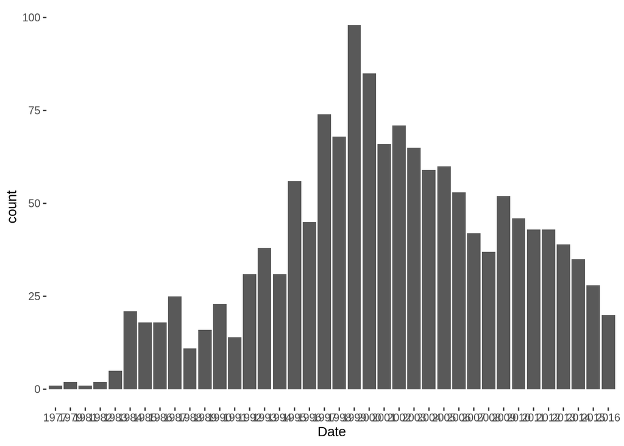

```r
ggplot(myDeathData, aes(Date))+geom_bar()
```

This is better! But, to show trends over time, a line graph is always better.

```r
# this doesn't work:
# ggplot(myDeathData, aes(Date))+geom_line()
```

Uh-oh! Line graphs need both x and y, i.e., we need to compute the totals for each year!

```r
head(myDeathData)
```

|  | Date | Name | Age | Sex | Race | Crime | Victim.Count | Victim.Sex | Victim.Race | County | State | Region | Method | Juvenile | Volunteer | Federal | Foreign.National |
| --- | --- | --- | --- | --- | --- | --- | --- | --- | --- | --- | --- | --- | --- | --- | --- | --- | --- |
| 1 | 1977 | Gary Gilmore | 36 | Male | White | Murder | 1 | Male | White | Utah | UT | West | Firing Squad | No | Yes | No | No |
| 2 | 1979 | John Spenkelink | 30 | Male | White | Murder | 1 | Male | White | Leon | FL | South | Electrocution | No | No | No | No |
| 3 | 1979 | Jesse Bishop | 46 | Male | White | Murder | 1 | Male | White | Clark | NV | West | Gas Chamber | No | Yes | No | No |
| 4 | 1981 | Steven Judy | 24 | Male | White | Murder | 4 | 2 Male, 2 Female | White | Marion | IN | Midwest | Electrocution | No | Yes | No | No |
| 5 | 1982 | Frank Coppola | 38 | Male | White | Murder | 1 | Male | White | Newport News City | VA | South | Electrocution | No | Yes | No | No |
| 6 | 1982 | Charlie Brooks | 40 | Male | Black | Murder | 1 | Male | White | Tarrant | TX | South | Lethal Injection | No | No | No | No |

We need some more tools to count up all the cases. First..

## Pipes

Pipes are a feature of dplyr. Look like this: %>%

Pipes let us chain together commands. Simple examples:

```r
## mean iris sepal length

mean(iris$Sepal.Length)
```

```
## [1] 5.843333
```

```r
## here's with pipes:

iris$Sepal.Length %>% mean
```

```
## [1] 5.843333
```

```r
## same thing!

iris$Sepal.Length %>% summary
```

```
##    Min. 1st Qu.  Median    Mean 3rd Qu.    Max.
##   4.300   5.100   5.800   5.843   6.400   7.900
```

This is super useful for chaining together many commands! Also useful because it works in the same order that you “think” about the operations.

Example: take iris data, filter all sepal lengths less than 5cm, filter only setosa species, then plot histogram

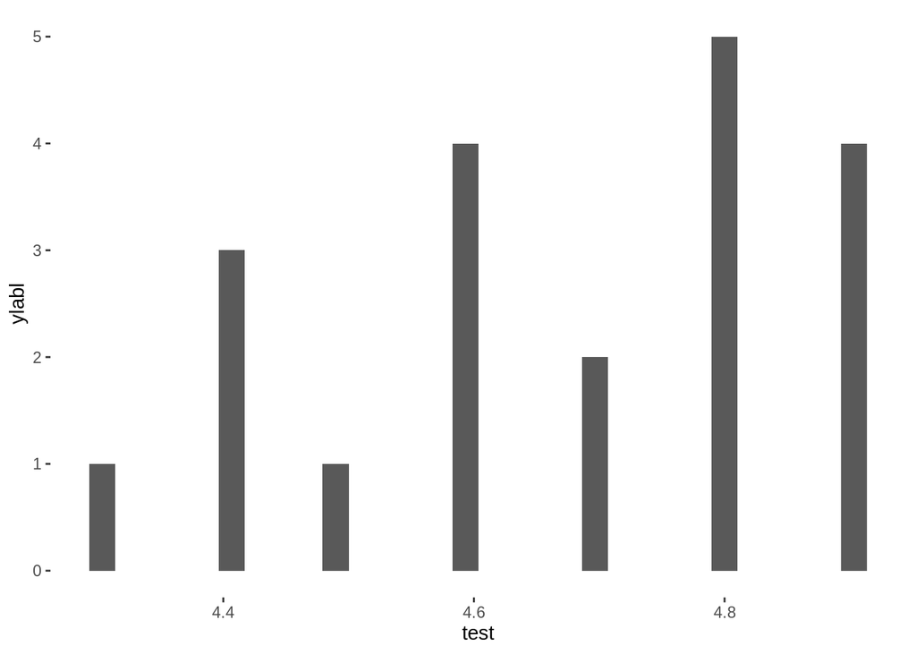

```r
iris %>%
  filter(Sepal.Length < 5) %>%
  filter(Species == "setosa") %>%
  ggplot(aes(Sepal.Length))+
  geom_histogram()+
  labs(x="test")+
  labs(y="ylabl")
```

```r
iris$Sepal.Length %>% mean
```

```
## [1] 5.843333
```

Example: Star Wars Data

```r
head(starwars)
```

| name | height | mass | hair_color | skin_color | eye_color | birth_year | gender | homeworld | species | films | vehicles | starships |
| --- | --- | --- | --- | --- | --- | --- | --- | --- | --- | --- | --- | --- |
| Luke Skywalker | 172 | 77 | blond | fair | blue | 19.0 | male | Tatooine | Human |  |  |  |
| C-3PO | 167 | 75 | NA | gold | yellow | 112.0 | NA | Tatooine | Droid |  |  |  |
| R2-D2 | 96 | 32 | NA | white, blue | red | 33.0 | NA | Naboo | Droid |  |  |  |
| Darth Vader | 202 | 136 | none | white | yellow | 41.9 | male | Tatooine | Human |  |  |  |
| Leia Organa | 150 | 49 | brown | light | brown | 19.0 | female | Alderaan | Human |  |  |  |
| Owen Lars | 178 | 120 | brown, grey | light | blue | 52.0 | male | Tatooine | Human |  |  |  |

Use pipes to answer:

- Make a list of all humans who are female

```r
starwars %>% filter(species == "Human") %>% filter(gender == "female")
```

| name | height | mass | hair_color | skin_color | eye_color | birth_year | gender | homeworld | species | films | vehicles | starships |
| --- | --- | --- | --- | --- | --- | --- | --- | --- | --- | --- | --- | --- |
| Leia Organa | 150 | 49 | brown | light | brown | 19 | female | Alderaan | Human |  |  |  |
| Beru Whitesun lars | 165 | 75 | brown | light | blue | 47 | female | Tatooine | Human |  |  |  |
| Mon Mothma | 150 | NA | auburn | fair | blue | 48 | female | Chandrila | Human |  |  |  |
| Shmi Skywalker | 163 | NA | black | fair | brown | 72 | female | Tatooine | Human |  |  |  |
| Cordé | 157 | NA | brown | light | brown | NA | female | Naboo | Human |  |  |  |
| Dormé | 165 | NA | brown | light | brown | NA | female | Naboo | Human |  |  |  |
| Jocasta Nu | 167 | NA | white | fair | blue | NA | female | Coruscant | Human |  |  |  |
| Rey | NA | NA | brown | light | hazel | NA | female | NA | Human |  |  |  |
| Padmé Amidala | 165 | 45 | brown | light | brown | 46 | female | Naboo | Human |  |  |  |

- Make a list of all female humans with brown eyes

```r
starwars %>%
  filter(species == "Human") %>%
  filter(gender == "female") %>%
  filter(eye_color == "brown")
```

| name | height | mass | hair_color | skin_color | eye_color | birth_year | gender | homeworld | species | films | vehicles | starships |
| --- | --- | --- | --- | --- | --- | --- | --- | --- | --- | --- | --- | --- |
| Leia Organa | 150 | 49 | brown | light | brown | 19 | female | Alderaan | Human |  |  |  |
| Shmi Skywalker | 163 | NA | black | fair | brown | 72 | female | Tatooine | Human |  |  |  |
| Cordé | 157 | NA | brown | light | brown | NA | female | Naboo | Human |  |  |  |
| Dormé | 165 | NA | brown | light | brown | NA | female | Naboo | Human |  |  |  |
| Padmé Amidala | 165 | 45 | brown | light | brown | 46 | female | Naboo | Human |  |  |  |

- Make a list of all female humans with brown eyes, hist of their height

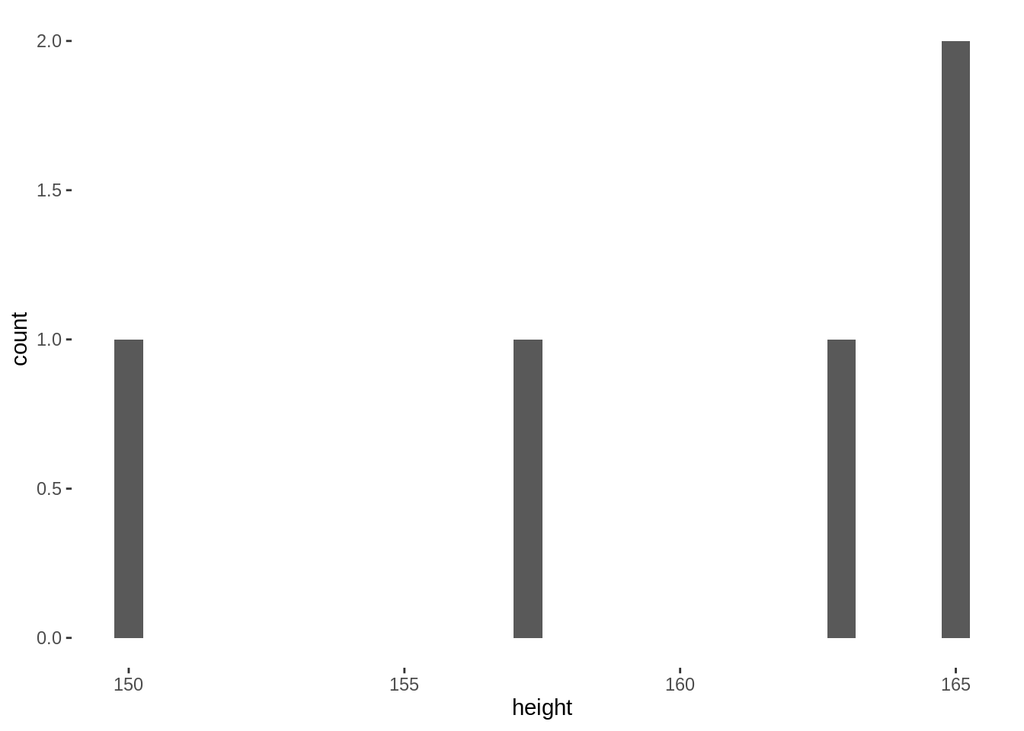

```r
starwars %>%
  filter(species == "Human") %>%
  filter(gender == "female") %>%
  filter(eye_color == "brown") %>%
  ggplot(aes(height))+geom_histogram()
```

## Super useful dplyr feature: group_by()

Often, we want to summarize by groups. Ex: in the iris dataset, find the mean Sepal Length for each species. Use group_by and summarise:

```r
iris %>% group_by(Species) %>% summarise(MeanSepal = mean(Sepal.Length))
```

| Species | MeanSepal |
| --- | --- |
| setosa | 5.006 |
| versicolor | 5.936 |
| virginica | 6.588 |

In summarise, you can use almost any function and add as many as you like:

```r
iris %>%
  group_by(Species) %>%
  summarise(MeanSepal = mean(Sepal.Length),
            StdevSepal = sd(Sepal.Length),
            MeanPetal = mean(Petal.Length),
            StdevPetal = sd(Petal.Length))
```

| Species | MeanSepal | StdevSepal | MeanPetal | StdevPetal |
| --- | --- | --- | --- | --- |
| setosa | 5.006 | 0.3524897 | 1.462 | 0.1736640 |
| versicolor | 5.936 | 0.5161711 | 4.260 | 0.4699110 |
| virginica | 6.588 | 0.6358796 | 5.552 | 0.5518947 |

Ex: Garlic Mustard

```r
gmdata <- read.csv("GarlicMustardData.csv")

head(gmdata)
```

|  | Pop_Code | Region | Collection_Date | Latitude | Longitude | Altitude | Pop_Size | Pct_Canopy_Cover | RosCount | AdultCount | RosDens | AdultDens | TotalDens | AvgRosWidth | AvgAdultHeight | AvgNLeaves | AvgNFruits | Herb | bio1 | bio2 | bio3 | bio4 | bio5 | bio6 | bio7 | bio8 | bio9 | bio10 | bio11 | … |
| --- | --- | --- | --- | --- | --- | --- | --- | --- | --- | --- | --- | --- | --- | --- | --- | --- | --- | --- | --- | --- | --- | --- | --- | --- | --- | --- | --- | --- | --- | --- |
| 1 | ABDAV1 | NorthAm | 10/1/10 | 41.55333 | -90.58442 | 191 | 200000 | 50 | 788 | 0 | 157.60 | 0.0 | 157.60 | 13.145833 | NA | NA | NA | NA | 9.934476 | 10.441296 | 0.2629619 | 0.03629305 | 29.1581 | -10.54840 | 39.70650 | 22.02654 | -3.89676976 | 22.40817 | -3.8967698 | … |
| 2 | ABDAV2 | NorthAm | 10/1/10 | 41.55176 | -90.58705 | 193 | 200000 | 80 | 59 | 0 | 14.75 | 0.0 | 14.75 | 10.333333 | NA | NA | NA | NA | 9.934476 | 10.441296 | 0.2629619 | 0.03629305 | 29.1581 | -10.54840 | 39.70650 | 22.02654 | -3.89676976 | 22.40817 | -3.8967698 | … |
| 3 | ABMRB1 | Europe | 5/23/10 | 46.58922 | 15.60067 | 379 | 5 | 10 | 0 | 123 | 0.00 | 82.0 | 82.00 | NA | 98.40000 | 11.600000 | 24.53333 | 0.22265512 | 8.562812 | 9.791023 | 0.3201027 | 0.02541682 | 24.4839 | -6.10323 | 30.58713 | 17.18422 | 0.06817604 | 17.48149 | -0.7929427 | … |
| 4 | ABSLB1 | NorthAm | 7/8/09 | 44.83333 | -86.02500 | 299 | 650 | 50 | 350 | 59 | 70.00 | 11.8 | 81.80 | 6.213043 | 70.14483 | 8.965517 | 17.13793 | 0.11052769 | 7.249963 | 9.917993 | 0.2744910 | 0.03240403 | 25.9323 | -10.20000 | 36.13230 | 14.72510 | -3.07018042 | 18.57427 | -4.7221618 | … |
| 5 | ABSLB2 | NorthAm | 7/8/09 | 44.89639 | -86.03361 | 223 | 1350 | 90 | 342 | 396 | 68.40 | 79.2 | 147.60 | 4.015217 | 39.94000 | 6.660000 | 6.56000 | 0.08177778 | 7.171334 | 9.875906 | 0.2724749 | 0.03250428 | 25.8452 | -10.40000 | 36.24520 | 14.73801 | -3.21864009 | 18.54206 | -4.8381028 | … |
| 6 | ADBRE1 | Europe | 6/20/11 | 47.23897 | 27.48869 | 172 | 100 | 70 | 21 | 176 | 4.20 | 35.2 | 39.40 | 6.916667 | 90.46512 | 12.395349 | 29.76744 | 0.40953301 | 9.659187 | 9.782758 | 0.2938903 | 0.02966553 | 26.4613 | -6.82581 | 33.28711 | 19.23335 | -1.18808889 | 19.73620 | -1.5845635 | … |

Ex: use group_by and summarize to find mean lat and lon for each region.

```r
gmdata %>%
  group_by(Region) %>%
  summarise(meanLat = mean(Latitude),
            meanLon = mean(Longitude))
```

| Region | meanLat | meanLon |
| --- | --- | --- |
| Europe | 49.69238 | 12.55643 |
| NorthAm | 41.16469 | -81.29662 |

Ex: Make a table with mean age of convicts who received death penalty by race.

```r
deathData %>%
  group_by(Race) %>%
  summarise(MeanAge = mean(Age))
```

| Race | MeanAge |
| --- | --- |
| Asian | 37.83333 |
| Black | 39.57576 |
| Latino | 38.47500 |
| Native American | 43.06250 |
| Other | 45.50000 |
| White | 43.08842 |

You can group by multiple variables! Ex: race and method.

```r
deathData %>%
  group_by(Race, Method) %>%
  summarise(MeanAge = mean(Age))
```

| Race | Method | MeanAge |
| --- | --- | --- |
| Asian | Lethal Injection | 37.83333 |
| Black | Electrocution | 38.35714 |
| Black | Gas Chamber | 29.66667 |
| Black | Lethal Injection | 39.84834 |
| Latino | Electrocution | 39.00000 |
| Latino | Lethal Injection | 38.47059 |
| Native American | Electrocution | 40.00000 |
| Native American | Lethal Injection | 43.26667 |
| Other | Lethal Injection | 45.50000 |
| White | Electrocution | 39.02326 |

[output cut: 4 more lines]

## An important group_by/summarize function: n()

The n() function counts how many cases. Useful for seeing how many!

Ex: Let’s make a table with counts by method:

```r
deathData %>%
  group_by(Method, Region) %>%
  summarise(Total = n() )
```

| Method | Region | Total |
| --- | --- | --- |
| Electrocution | Midwest | 6 |
| Electrocution | South | 152 |
| Firing Squad | West | 3 |
| Gas Chamber | South | 6 |
| Gas Chamber | West | 5 |
| Hanging | South | 1 |
| Hanging | West | 2 |
| Lethal Injection | Midwest | 172 |
| Lethal Injection | Northeast | 4 |
| Lethal Injection | South | 1016 |

[output cut: 1 more lines]

## Line graph for death penalty

First, wrangle the date

```r
head(deathData)
```

|  | Date | Name | Age | Sex | Race | Crime | Victim.Count | Victim.Sex | Victim.Race | County | State | Region | Method | Juvenile | Volunteer | Federal | Foreign.National |
| --- | --- | --- | --- | --- | --- | --- | --- | --- | --- | --- | --- | --- | --- | --- | --- | --- | --- |
| 1 | 01/17/1977 | Gary Gilmore | 36 | Male | White | Murder | 1 | Male | White | Utah | UT | West | Firing Squad | No | Yes | No | No |
| 2 | 05/25/1979 | John Spenkelink | 30 | Male | White | Murder | 1 | Male | White | Leon | FL | South | Electrocution | No | No | No | No |
| 3 | 10/22/1979 | Jesse Bishop | 46 | Male | White | Murder | 1 | Male | White | Clark | NV | West | Gas Chamber | No | Yes | No | No |
| 4 | 03/09/1981 | Steven Judy | 24 | Male | White | Murder | 4 | 2 Male, 2 Female | White | Marion | IN | Midwest | Electrocution | No | Yes | No | No |
| 5 | 08/10/1982 | Frank Coppola | 38 | Male | White | Murder | 1 | Male | White | Newport News City | VA | South | Electrocution | No | Yes | No | No |
| 6 | 12/07/1982 | Charlie Brooks | 40 | Male | Black | Murder | 1 | Male | White | Tarrant | TX | South | Lethal Injection | No | No | No | No |

```r
as.Date(deathData$Date, "%m/%d/%Y")
```

```
##    [1] "1977-01-17" "1979-05-25" "1979-10-22" "1981-03-09" "1982-08-10"
##    [6] "1982-12-07" "1983-04-22" "1983-09-02" "1983-11-30" "1983-12-14"
##   [11] "1983-12-15" "1984-01-26" "1984-02-29" "1984-03-14" "1984-03-16"
##   [16] "1984-03-31" "1984-04-05" "1984-04-05" "1984-05-10" "1984-06-20"
##   [21] "1984-07-12" "1984-07-13" "1984-09-07" "1984-09-10" "1984-09-20"
##   [26] "1984-10-12" "1984-10-30" "1984-10-30" "1984-11-02" "1984-11-08"
##   [31] "1984-12-12" "1984-12-28" "1985-01-04" "1985-01-09" "1985-01-11"
##   [36] "1985-01-16" "1985-01-30" "1985-02-20" "1985-03-06" "1985-03-13"
##   [41] "1985-03-20" "1985-04-18" "1985-05-15" "1985-05-29" "1985-06-25"
##   [46] "1985-06-25" "1985-07-09" "1985-09-11" "1985-10-16" "1985-12-06"
##   [51] "1986-01-10" "1986-03-12" "1986-03-21" "1986-04-15" "1986-04-16"
##   [56] "1986-04-22" "1986-05-15" "1986-05-20" "1986-06-09" "1986-06-19"
##   [61] "1986-06-24" "1986-07-31" "1986-08-20" "1986-08-22" "1986-08-26"
##   [66] "1986-09-19" "1986-12-04" "1986-12-18" "1987-01-30" "1987-03-04"
##   [71] "1987-05-15" "1987-05-20" "1987-05-22" "1987-05-28" "1987-05-29"
```

[output cut: 274 more lines]

```r
## make a backup!!!!  if you do it wrong, you wreck your data!

deathDataBackup <- deathData

#over-write the date

deathDataBackup$Date <- as.Date(deathData$Date, "%m/%d/%Y")

head(deathDataBackup)
```

|  | Date | Name | Age | Sex | Race | Crime | Victim.Count | Victim.Sex | Victim.Race | County | State | Region | Method | Juvenile | Volunteer | Federal | Foreign.National |
| --- | --- | --- | --- | --- | --- | --- | --- | --- | --- | --- | --- | --- | --- | --- | --- | --- | --- |
| 1 | 1977-01-17 | Gary Gilmore | 36 | Male | White | Murder | 1 | Male | White | Utah | UT | West | Firing Squad | No | Yes | No | No |
| 2 | 1979-05-25 | John Spenkelink | 30 | Male | White | Murder | 1 | Male | White | Leon | FL | South | Electrocution | No | No | No | No |
| 3 | 1979-10-22 | Jesse Bishop | 46 | Male | White | Murder | 1 | Male | White | Clark | NV | West | Gas Chamber | No | Yes | No | No |
| 4 | 1981-03-09 | Steven Judy | 24 | Male | White | Murder | 4 | 2 Male, 2 Female | White | Marion | IN | Midwest | Electrocution | No | Yes | No | No |
| 5 | 1982-08-10 | Frank Coppola | 38 | Male | White | Murder | 1 | Male | White | Newport News City | VA | South | Electrocution | No | Yes | No | No |
| 6 | 1982-12-07 | Charlie Brooks | 40 | Male | Black | Murder | 1 | Male | White | Tarrant | TX | South | Lethal Injection | No | No | No | No |

```r
# cool!  need year.  use format()

format(deathDataBackup$Date, "%Y")
```

```
##    [1] "1977" "1979" "1979" "1981" "1982" "1982" "1983" "1983" "1983"
##   [10] "1983" "1983" "1984" "1984" "1984" "1984" "1984" "1984" "1984"
##   [19] "1984" "1984" "1984" "1984" "1984" "1984" "1984" "1984" "1984"
##   [28] "1984" "1984" "1984" "1984" "1984" "1985" "1985" "1985" "1985"
##   [37] "1985" "1985" "1985" "1985" "1985" "1985" "1985" "1985" "1985"
##   [46] "1985" "1985" "1985" "1985" "1985" "1986" "1986" "1986" "1986"
##   [55] "1986" "1986" "1986" "1986" "1986" "1986" "1986" "1986" "1986"
##   [64] "1986" "1986" "1986" "1986" "1986" "1987" "1987" "1987" "1987"
##   [73] "1987" "1987" "1987" "1987" "1987" "1987" "1987" "1987" "1987"
##   [82] "1987" "1987" "1987" "1987" "1987" "1987" "1987" "1987" "1987"
##   [91] "1987" "1987" "1987" "1988" "1988" "1988" "1988" "1988" "1988"
##  [100] "1988" "1988" "1988" "1988" "1988" "1989" "1989" "1989" "1989"
##  [109] "1989" "1989" "1989" "1989" "1989" "1989" "1989" "1989" "1989"
##  [118] "1989" "1989" "1989" "1990" "1990" "1990" "1990" "1990" "1990"
##  [127] "1990" "1990" "1990" "1990" "1990" "1990" "1990" "1990" "1990"
```

[output cut: 146 more lines]

```r
# now overwrite

deathDataBackup$Date <- format(deathDataBackup$Date, "%Y")

head(deathDataBackup)
```

|  | Date | Name | Age | Sex | Race | Crime | Victim.Count | Victim.Sex | Victim.Race | County | State | Region | Method | Juvenile | Volunteer | Federal | Foreign.National |
| --- | --- | --- | --- | --- | --- | --- | --- | --- | --- | --- | --- | --- | --- | --- | --- | --- | --- |
| 1 | 1977 | Gary Gilmore | 36 | Male | White | Murder | 1 | Male | White | Utah | UT | West | Firing Squad | No | Yes | No | No |
| 2 | 1979 | John Spenkelink | 30 | Male | White | Murder | 1 | Male | White | Leon | FL | South | Electrocution | No | No | No | No |
| 3 | 1979 | Jesse Bishop | 46 | Male | White | Murder | 1 | Male | White | Clark | NV | West | Gas Chamber | No | Yes | No | No |
| 4 | 1981 | Steven Judy | 24 | Male | White | Murder | 4 | 2 Male, 2 Female | White | Marion | IN | Midwest | Electrocution | No | Yes | No | No |
| 5 | 1982 | Frank Coppola | 38 | Male | White | Murder | 1 | Male | White | Newport News City | VA | South | Electrocution | No | Yes | No | No |
| 6 | 1982 | Charlie Brooks | 40 | Male | Black | Murder | 1 | Male | White | Tarrant | TX | South | Lethal Injection | No | No | No | No |

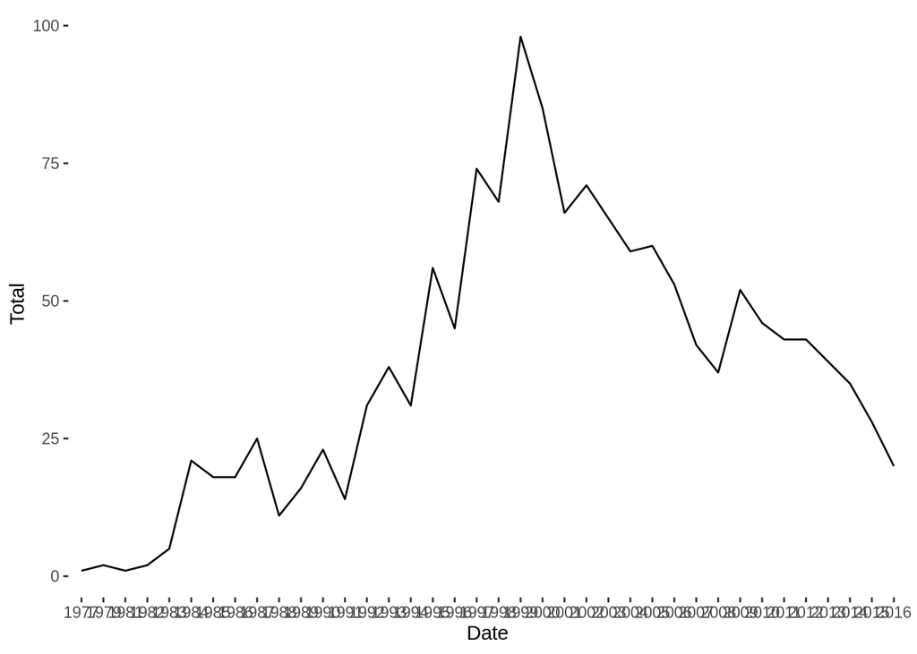

```r
#Cool, got the year.  Let's a make a table with the counts n() for each year

deathDataBackup %>%
  group_by(Date) %>%
  summarise(Total = n()) %>%
  ggplot(aes(x=Date, y=Total, group=1))+geom_line()
```